# Third Places & Urban Segregation

Agent-Based Modeling, Parameter Sweeps, and Public Exploranation

Vsevolod Suschevskiy & Benjamin Jarvis

Linköping University

## The Illusion of Simple Fixes

### Segregation as an Emergent Trap

- Residential sorting emerges from decentralized household relocations[cite: 2, 3].
- Intuitive spatial fixes often trigger **unintended consequences**[cite: 2, 3].
- *Historical precedent:* 1970s Boston school busing aimed to force desegregation overnight; it catalyzed suburban white flight and rapid re-segregation[cite: 3].
- Spatial amenities (“third places”) shape opportunity structures, but how do they interact with residential choice[cite: 1, 2]?

> *“The writer points to real, concrete things so the reader can see them clearly.”*

> When policies attempt to mechanically shift populations without addressing underlying utility, the emergent system pushes back[cite: 2, 3].

## Analytical Framing: Coleman’s Boat

Connecting macro urban policy interventions to aggregate segregation indices through micro decision rules[cite: 2, 3].

### Definitions & Core Question

- **Segregation:** Group separation measured across unevenness, exposure, and clustering[cite: 1, 2].
- **Venues (“Third Places”):** Everyday non-work destinations (cafés, parks, hubs) with defined catchments and social utility[cite: 1, 2].
- **Research Question:** Does altering local amenity structures mitigate or entrench residential segregation[cite: 1, 2]?

## Model Architecture: Space as a Layered Network

### Extending Schelling

- **Street Networks:** Connected paths define local neighborhood interaction[cite: 1, 2].
- **Highways as Barriers:** Function as structural breaks cutting across ties[cite: 1, 2].
- **Venues as Anchors:** Third places offer social utility based on catchment radius and group match[cite: 1, 2].
- **Relocation Rule:** Bottom 10% least satisfied agents move each tick to open vacancies[cite: 1, 2].

### Agent Utility Formulation

$$\text{Utility} = \frac{\sum (\beta_i \cdot \text{Attribute}_i)}{\sum \beta} + \epsilon$$

- $\beta_1$: Residential neighbors[cite: 2]
- $\beta_2$: Venue group match[cite: 2]
- $\beta_3 \dots \beta_6$: Road access, parks, distance[cite: 2]

## The Tale of Two Scales: Meso vs. Macro

### City-Wide Integration (Tick 600)

- **Intervention:** Symmetrical model-wide integrated venue network[cite: 1].
- **Macro Fracture:** Dissimilarity drops by **0.055** (~5.5% minority population reallocated into integrated zones)[cite: 1].
- Overlapping catchment areas break the necessity of living in segregated residential enclaves[cite: 1].

## Systematic Experiments: Utility Trade-Offs

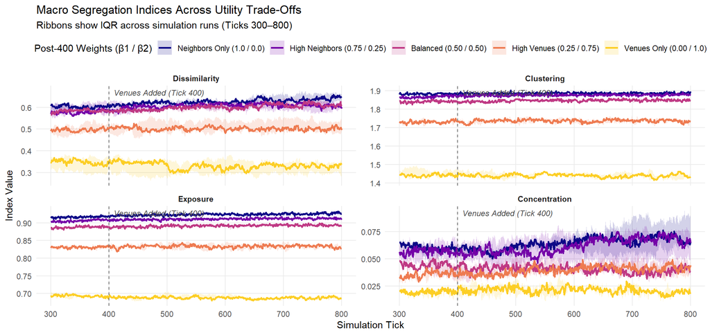

Figure 1

## Systematic Experiments: Venue Exclusivity

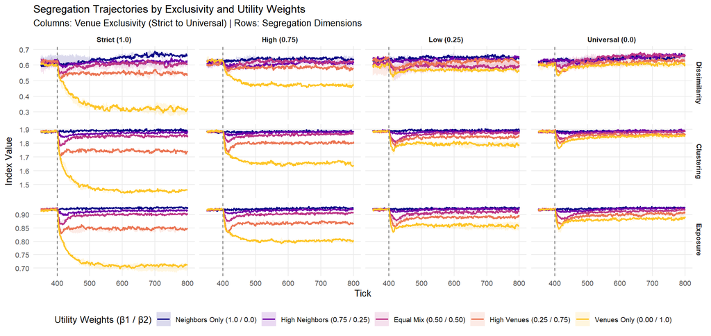

Figure 2

## Bridging the Gap: Code to Lived Reality

### The Analyst’s Parameter Space

- Abstract coordinates and toroidal distances
- Beta weights ($\beta_1 = 0.5, \beta_2 = 0.5$)[cite: 2]
- Catchment buffers and dissimilarity curves[cite: 1, 2]
- Static mathematical formulations of sorting[cite: 1, 2]

### The Everyday Urban Reality

- *“The good school”* (Denton, 1995)[cite: 2]
- *“The nearby workplace”* (Clark et al., 2003)[cite: 2]
- *“The grocery store with the right milk”* (Clark et al., 2002)[cite: 2]
- Commercial zoning variance and community center funding[cite: 1, 2]

> **The Computational Social Science Dilemma:** If our models remain locked in NetLogo widgets and R scripts, computational sociology produces authoritative black-box answers rather than empowering civic understanding[cite: 1, 2].

## Public Exploranation: The Norrköping Exhibit

### Principles from *Data Feminism*

- **Examine & Challenge Power:** Scrutinize who builds models and what assumptions govern them[cite: 1].
- **Elevate Emotion & Embodiment:** Replace passive, detached charts with tactile, interactive exploration[cite: 1].
- **Exploranation Paradigm:** Merging scientific visualization research with public museum installations (Visual Sweden / Norrköping)[cite: 1, 2, 3].

### Tangible Urban Tabletop

- Visitors interact with an illuminated physical tabletop projection of Norrköping[cite: 1, 2, 3].
- Placing physical venue props triggers real-time NetLogo re-simulation[cite: 1, 2].
- Shifts visitors from passive consumers of data to active experimenters probing unintended policy consequences[cite: 1, 2].

## Takeaways

### 1. Third Places Matter

Venues are not passive backgrounds; they actively restructure the spatial opportunity matrix of cities[cite: 1, 2].

### 3. Open the Model

Democratizing computational sociology requires physical, interactive exploranations for public deliberation[cite: 1, 2].

**Thank you!**  
*Vsevolod Suschevskiy* | Linköping University[cite: 1, 2]  
Questions & Discussion[cite: 1]